# Documentation for the SUNFLO crop model

# Model structure

## Modules

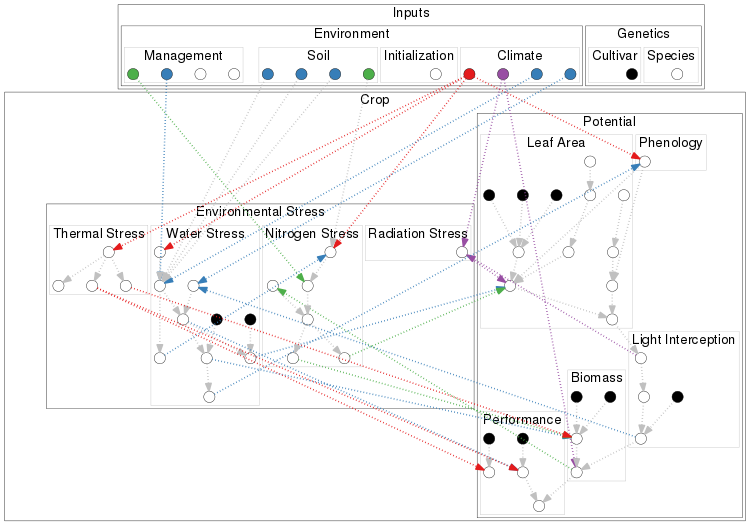

## Variables

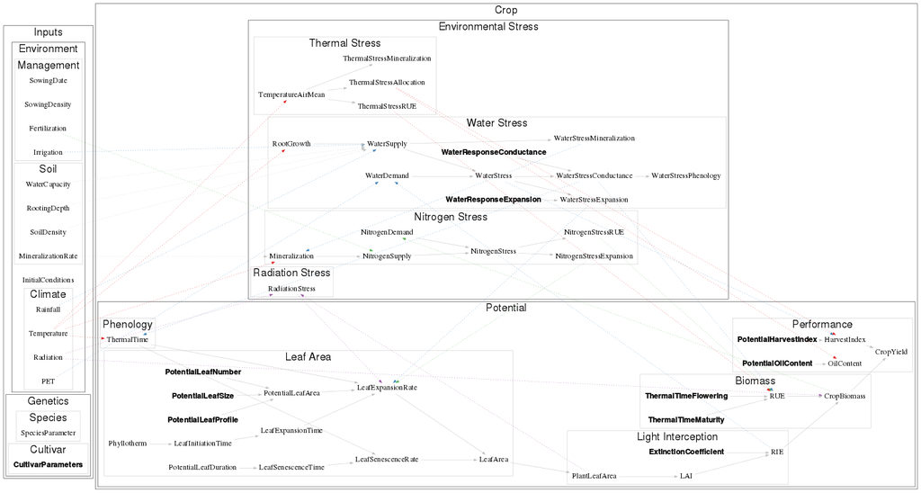

## Environment

### Climate

| label | description | unit |
| --- | --- | --- |
| TemperatureAirMin | Minimum air temperature | °C |
| TemperatureAirMax | Maximum air temperature | °C |
| Radiation | Global incident radiation | MJ.m-2 |
| PET | Reference evapotranspiration | mm |
| Rainfall | Rainfall | mm |

### Soil

| label | description | value | unit | reference |
| --- | --- | --- | --- | --- |
| RootingDepth | Potential rooting depth | 1800 | mm | (Lecoeur et al., 2011) |
| WaterCapacity | Water content at field capacity (0-30 cm) | 19.69 | % |  |
| WaterCapacity | Water content at wilting point (0-30cm) | 9.69 | % |  |
| WaterCapacity | Water content at field capacity (30 cm-rooting depth) | 19.69 | % |  |
| WaterCapacity | Water content at wilting point (30 cm-rooting depth) | 9.69 | % |  |
| SoilDensity | Soil bulk density (0-30cm) | 1.5 | g.cm-3 |  |
| SoilDensity | Soil bulk density (30 cm-rooting depth) | 1.5 | g.cm-3 |  |
| StoneContent | Stone content (0-rooting depth) | 0 | [0 ; 1] |  |
| MineralizationRate | Potential nitrogen mineralization rate | 0.5 | kg/ha/day (normalized) | (Valé et al., 2007) |

### Management

| label | description | value | unit | reference |
| --- | --- | --- | --- | --- |
| SowingDate | Sowing date |  | dd/mm |  |
| HarvestDate | Harvest date |  | dd/mm |  |
| SowingDensity | Plant density | 6.8 | pnt/m2 |  |
| Fertilization | Fertilization (date 1) |  | dd/mm |  |
| Fertilization | Fertilization (amount 1) | 0 | kg/ha eq. mineral nitrogen |  |
| Fertilization | Fertilization (date 2) |  | dd/mm |  |
| Fertilization | Fertilization (amount 2) | 0 | kg/ha eq. mineral nitrogen |  |
| Irrigation | Irrigation (date 1) |  | dd/mm |  |
| Irrigation | Irrigation (amount 1) | 0 | mm |  |
| Irrigation | Irrigation (date 2) |  | dd/mm |  |
| Irrigation | Irrigation (amount 2) | 0 | mm |  |
| Irrigation | Irrigation (date 3) |  | dd/mm |  |
| Irrigation | Irrigation (amount 3) | 0 | mm |  |

## Genetics

### Species

### Cultivar

value

unit

reference

ThermalTimeVegetative

Temperature sum to floral initiation

482

°Cd

(Lecoeur et al., 2011)

ThermalTimeFlowering

Temperature sum from emergence to the beginning of flowering

836

°Cd

(Lecoeur et al., 2011)

ThermalTimeSenescence

Temperature sum from emergence to the beginning of grain filling

1083

°Cd

(Lecoeur et al., 2011)

ThermalTimeMaturity

Temperature sum from emergence to seed physiological maturity

1673

°Cd

(Lecoeur et al., 2011)

PotentialLeafNumber

Potential number of leaves at flowering

29

leaf

(Lecoeur et al., 2011)

PotentialLeafProfile

Potential rank of the largest leave of leaf profile at flowering

17

leaf

(Lecoeur et al., 2011)

PotentialLeafSize

Potential area of the largest leave of leaf profile at flowering

448

cm2

(Lecoeur et al., 2011)

ExtinctionCoefficient

Light extinction coefficient during vegetative growth

0.88

(Lecoeur et al., 2011)

WaterResponseExpansion

Threshold for leaf expansion response to water stress

-4.42

(Casadebaig et al., 2008)

WaterResponseConductance

Threshold for stomatal conductance response to water stress

-9.3

(Casadebaig et al., 2008)

PotentialHarvestIndex

Potential harvest index

0.398

(Casadebaig et al., 2011)

PotentialOilContent

Potential seed oil content

55.4

% dry matter

(Casadebaig et al., 2011)

# Crop potential growth

## Phenology

| label | description | value | unit | reference |
| --- | --- | --- | --- | --- |
| ThermalTimeVegetative | Temperature sum to floral initiation | 482 | °Cd | (Lecoeur et al., 2011) |
| ThermalTimeFlowering | Temperature sum from emergence to the beginning of flowering | 836 | °Cd | (Lecoeur et al., 2011) |
| ThermalTimeSenescence | Temperature sum from emergence to the beginning of grain filling | 1083 | °Cd | (Lecoeur et al., 2011) |
| ThermalTimeMaturity | Temperature sum from emergence to seed physiological maturity | 1673 | °Cd | (Lecoeur et al., 2011) |
| SowingDepth | Sowing depth | 30 | mm |  |
| Germination | Temperature sum from sowing to germination | 86.2 | °Cd | (Villalobos et al., 1996) |
| ElongationRate | Reciprocal of hypocotyl elongation rate | 1.19 | °Cd/mm | (Villalobos et al., 1996) |

### Emergence

$Emergence = Germination + ElongationRate \cdot SowingDepth$

with : $Germination = 86$, Thermal time for germination (°C.d) (Casadebaig et al., 2011) ; $ElongationRate = 1.19$, Hypocotyl elongation rate (°Cd/mm) (Villalobos et al., 1996) ; $SowingDepth = 30$, Sowing depth (mm).

### ThermalTime

$ThermalTime_d= \left\{ \begin{array}{ll} \int_0^d (T_m - T_b) \cdot (1 + WaterStressPhenology) \cdot dt & \textrm{if $T_m > T_b$} \\ 0 & \textrm{else} \end{array} \right.$

### PhenoStages

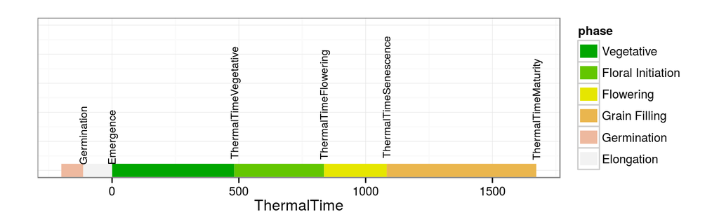

## LeafArea

[output not shown]

### LeafInitiationTime, LeafExpansionTime, LeafSenescenceTime

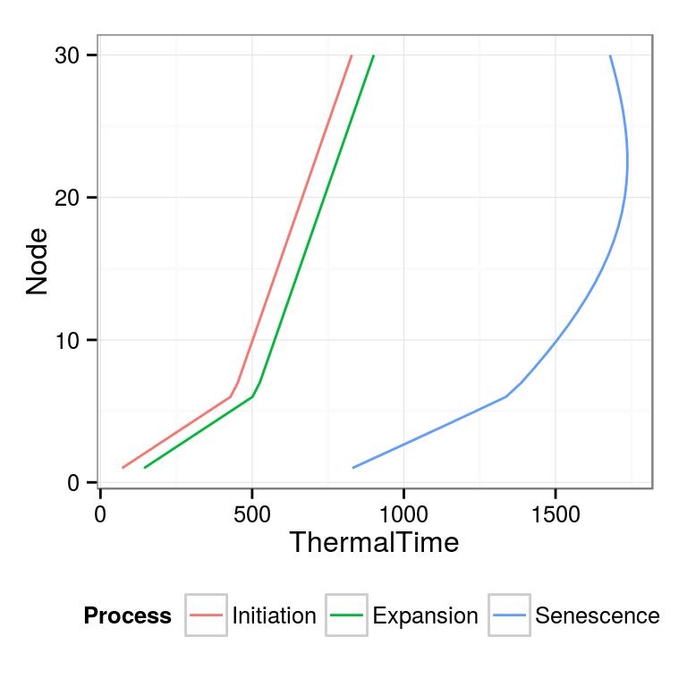

$LeafInitiationTime_i = \left\{ \begin{array}{ll} i \cdot Phyllotherm_1 & \textrm{if $i \leq 6$} \\ (i-5) \cdot Phyllotherm_7 + a & \textrm{if $i \leq LeafNumber$} \end{array} \right.$

$LeafExpansionTime_i=LeafInitiation_i + 1/a$

with $a=0.01379$.

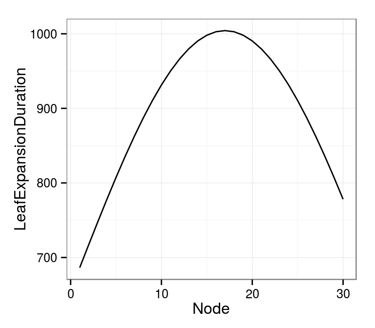

$LeafExpansionDuration_i = a + PotentialLeafDuration \cdot exp^{\frac{-(i-PotentialLeafProfile)^2}{(c \cdot PotentialLeafNumber)^2}}$

with $PotentialLeafDuration=851.3$ (°C.d), $a=153$ (°C.d), $b=0.78$

$LeafSenescenceTime_i = LeafExpansionTime_i + LeafExpansionDuration_i$

### PotentialLeafArea

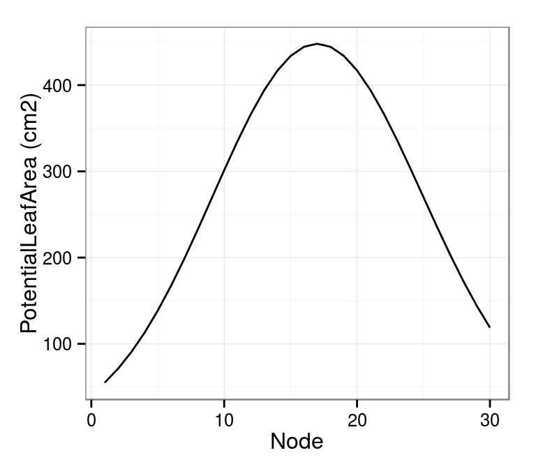

$PotentialLeafArea_i = PotentialLeafSize \cdot exp^{a \cdot (\frac{i-PotentialLeafProfile}{PotentialLeafProfile-1})^2 + b \cdot (\frac{i-PotentialLeafProfile}{PotentialLeafProfile-1})^3}$

with $a=-2.05$ and $b=0.049$, shape parameters; $PotentialLeafSize$ (cm2) and $PotentialLeafProfile$ (node), genotypic parameters.

### LeafGrowthRate, LeafSenescenceRate, LeafArea

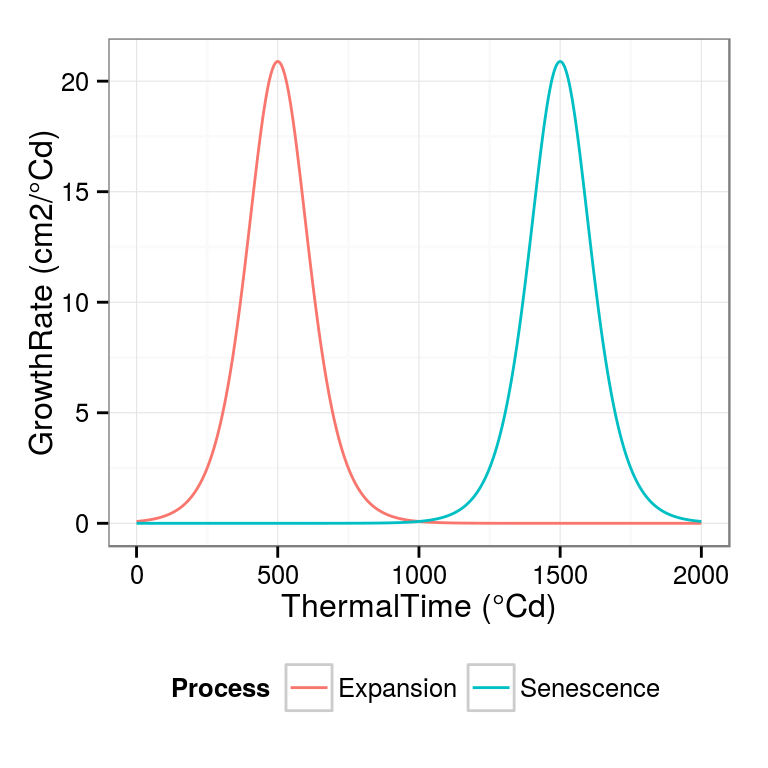

$LeafGrowthRate_i = (T_m - T_b) \cdot PotentialLeafArea_i \cdot a \cdot \frac{exp^{-a(ThermalTime-LeafExpansionTime_i)}}{(1+exp^{-a(ThermalTime-LeafExpansionTime_i)})^2}$

$LeafSenescenceRate_i = (T_m - T_b) \cdot LeafArea_i \cdot a \cdot \frac{exp^{-a(ThermalTime-LeafSenescenceTime_i)}}{(1+exp^{-a(ThermalTime-LeafSenescenceTime_i)})^2}$

with $T_m=25$, mean air temperature (°C); $T_b=4.8$, base temperature (°C); $a=0.01379$.  
The illustration uses $i=10$ as values for $PotentialLeafArea_i$, $LeafExpansionTime_i$ and $LeafSenescenceTime_i$

$LeafArea_i=\int LeafGrowthRate_i - \int LeafSenescenceRate_i$

## Light interception

### LAI

$LAI = \sum_{i=1}^{LeafNumber} LeafArea_i$

### RIE

$RIE = 1 - exp^{(-ExtinctionCoefficient * LAI)}$

## Biomass production

### RUE

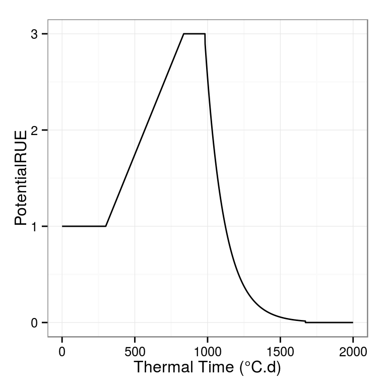

$PotentialRUE = \left\{ \begin{array}{ll} r_0 & \textrm{if $ThermalTime < 300 $} \\ r_0 + 2 \cdot \frac{ThermalTime-300}{ThermalTimeFlowering-300} & \textrm{if $300 < ThermalTime < ThermalTimeFlowering$}\\ r_{max} & \textrm{if $ThermalTimeFlowering < ThermalTime < ThermalTimeSenescence$}\\ a \cdot exp^{b \cdot (1-\frac{ThermalTime - ThermalTimeMaturity}{ThermalTimeMaturity - ThermalTimeSenescence})} & \textrm{if $ThermalTimeSenescence < ThermalTime < ThermalTimeMaturity$}\\ 0 & \textrm{else} \end{array} \right.$

with $r_0=1$, vegetative RUE; $r_{max}=3$, maximum RUE; $a=0.015$, final RUE; $b=4.5$, slope of RUE decrease in grain filling stage.

### CropBiomass (Monteith, 1977)

$dCropBiomass = 0.48 \cdot Radiation \cdot RIE \cdot RUE \cdot dt$

## Crop performance

# Environmental factors limiting crop production

## Thermal stress

### ThermalStressRUE (Villalobos et al., 1996)

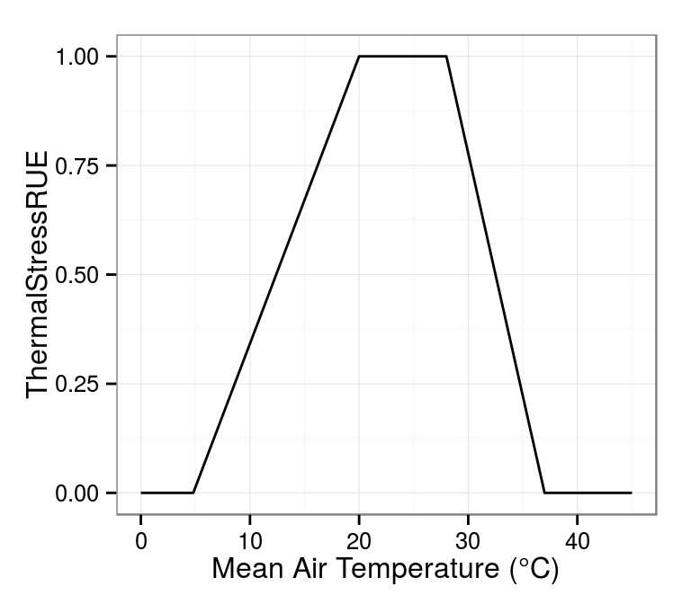

$ThermalStressRUE = \left\{ \begin{array}{ll} T_m \cdot \frac{1}{T_{ol} - T_b} - \frac{T_b}{T_{ol} - T_b} & \textrm{if $T_b < T_m < T_{ol}$} \\ 1 & \textrm{if $T_{ol} < T_m < T_{ou}$} \\ T_m \cdot \frac{1}{T_{ou} - tc} - \frac{tc}{T_{ou} - tc} & \textrm{if $T_{ou} < T_m < tc$} \\ 0 & \textrm{else} \end{array} \right.$

with $T_b = 4.8$, base temperature (°C); $T_{ol} = 20$, optimal lower temperature (°C); $T_{ou} = 28$, optimal upper temperature (°C); $T_c = 37$, critical temperature (°C)

### ThermalStressMineralization (Valé et al., 2007)

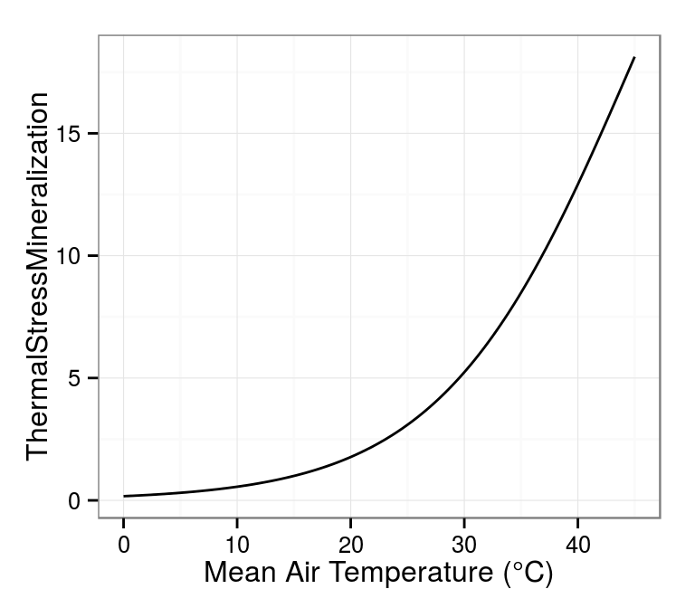

$ThermalStressMineralization = \frac{T_c}{1 + (T_c - 1) \cdot exp^{(-0.119 \cdot (T_m - T_b))}}$

with $T_b = 15$, base temperature (°C); $T_c = 36$, critical temperature (°C)

### ThermalStressAllocation

## Water stress

### WaterStressExpansion, WaterStressConductance

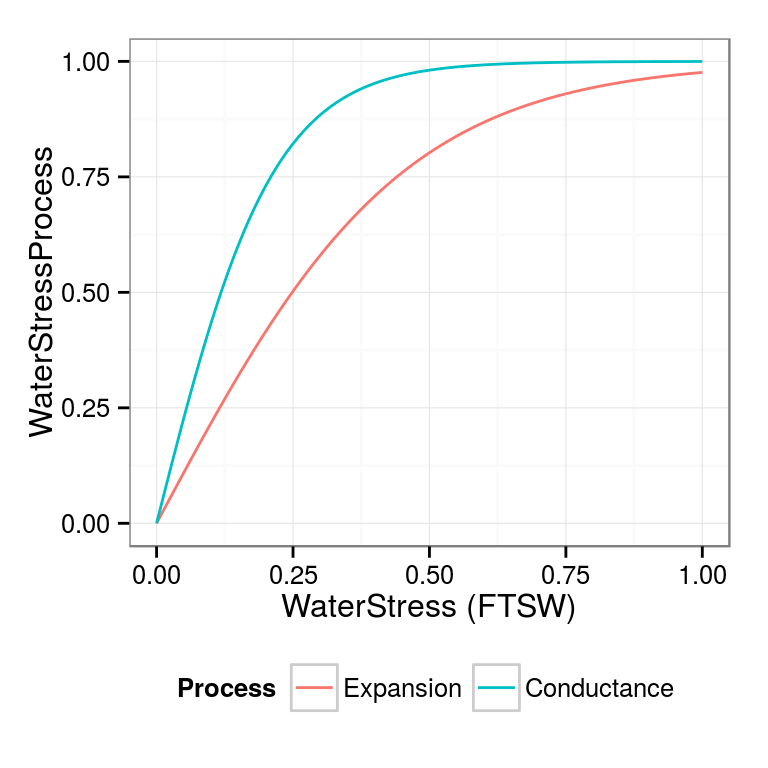

$WaterStressProcess = -1 + \frac{2}{1 + exp^{(a \cdot WaterStress)}}$

with $a \in [-15.6;-2.3]$, genotype-dependant response parameter

### WaterStressPhenology

$WaterStressPhenology = a \cdot (1 - WaterStressConductance)$ with $a=0.1$, scaling parameter for water-stress plant heating

### WaterStressMineralization

$WaterStressMineralization = 1 - (1 - y_0) \cdot (1 - RelativeWaterContent_{layer1})$

## Nitrogen stress

## Radiation stress

### RadiationStressExpansion (Rey, 2003)

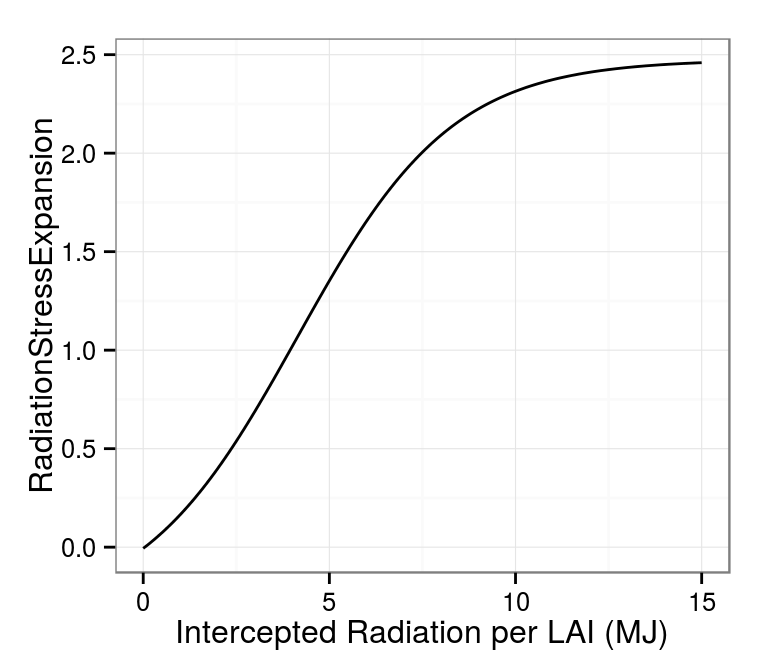

with $s=2.5$, scaling parameter for density effect; $a=-0.14$; $b=1.13$; $c=4.13$; $d=2.09$

References

Casadebaig, P., Debaeke, P., Lecoeur, J., 2008. Thresholds for leaf expansion and transpiration response to soil water deficit in a range of sunflower genotypes. European Journal of Agronomy 28, 646–654.

Casadebaig, P., Guilioni, L., Lecoeur, J., Christophe, A., Champolivier, L., Debaeke, P., 2011. SUNFLO, a model to simulate genotype-specific performance of the sunflower crop in contrasting environments. Agricultural and Forest Meteorology 151, 163–178.

Granier, C., Tardieu, F., 1998. Is thermal time adequate for expressing the effects of temperature on sunflower leaf development? Plant, Cell & Environment 21, 695–703.

Lecoeur, J., Poiré-Lassus, R., Christophe, A., Pallas, B., Casadebaig, P., Debaeke, P., Vear, F., Guilioni, L., 2011. Quantifying physiological determinants of genetic variation for yield potential in sunflower. SUNFLO: a model-based analysis. Functional Plant Biology 38, 246–259.

Monteith, J.L., 1977. Climate and the Efficiency of Crop Production in Britain. Philosophical Transactions of the Royal Society of London. Series B, Biological Sciences 281, 277–294.

Rey, H., 2003. Utilisation de la modélisation 3D pour l’analyse et la simulation du développement et de la croissance végétative d’une plante de tournesol en conditions environnementales fluctuantes (température et rayonnement). (PhD thesis). Ecole Nationale Supérieure Agronomique de Montpellier, spécialité sciences agronomiques, CIRAD-AMAP / INRA - LEPSE.

Valé, M., Mary, B., Justes, E., 2007. Irrigation practices may affect denitrification more than nitrogen mineralization in warm climatic conditions. Biology and Fertility of Soils 43, 641–651.

Villalobos, F., Hall, A., Ritchie, J., Orgaz, F., 1996. OILCROP-SUN: a development, growth and yield model of the sunflower crop. Agronomy Journal 88, 403–415.